# Integrating spectral flow and CyTOF data

Christina Bligaard Pedersen

February 19, 2021

This vignette will demonstrate the integration of spectral flow cytometry (SFC) and CyTOF protein expression measurements using cyCombine.

## Paired dataset

The dataset we will use for this demonstration originates from [Ferrer-Font et al. (2020)](https://doi.org/10.1002/cyto.a.24016), who studied the comparability of CyTOF and SFC data. They used splenocytes from the same samples which had been quantified using the two technologies and were able to conclude that the results were indeed very similar. However, this analysis was carried out by analyzing the sets separately. Here, we would like to demonstrate the *direct* integration of the sets.

According to the article, the SFC panel of this study contained 21 protein markers, and the CyTOF panel comprised 36 markers. 20 of these were overlapping. A total of five samples are included for each technology, and they are stored at FlowRepository (ID: FR-FCM-Z2GZ) or [GitHub](https://github.com/SameOldSamOld/CyTOFAuroraComparison). All files were downsampled to 19,858 cells in the analysis of the article and the uploaded FCS files. We downloaded these and relied on one of the GitHub scripts for accurate mapping of channels and markers.

In the original study, they focused on 11 immune cell populations, which were manually gated. Some of these assignments overlap - i.e. T cells were considered as a combined population and after gating on CD4/CD8. The included populations were “T cells”, “CD4 T cells”, “CD8 T cells”, “DN T cells”, “B cells”, “NK cells”, “Monocytes”, “DCs”, “DC1s”, “DC2s”, and “Neutrophils”. However, the authors have not shared the cell labels in their FCS files, so we replicated their gating to the best of our ability.

It was already established that the frequencies of these populations correlated nicely between the two technologies, however the article also states that they were unable to overlay the two data types due to the different data structures of the platforms. With this in mind, we enter the path of cyCombine.

We start by loading some packages

```r
library(cyCombine)
library(tidyverse)
```

#### Loading data

##### Spectral flow cytometry data

We are now ready to load the spectral flow data. We have set up a panel file in csv format, so the correct information is extractable from there. Let us have a look at the contents:

```r
# Directory with raw .fcs files
data_dir <- "FR-FCM-Z2GZ/SFC/"

# Panel and reading data
sfc_panel <- read_csv(paste0(data_dir, "/panel_sfc.csv"))
sfc_panel
```

| Channel | Marker | Type |
| --- | --- | --- |
| FSC-A | FSC-A | none |
| FSC-H | FSC-H | none |
| FSC-W | FSC-W | none |
| SSC-A | SSC-A | none |
| SSC-H | SSC-H | none |
| SSC-W | SSC-W | none |
| FJComp-AF-A | FJComp-AF-A | none |
| FJComp-APC-A | KLRG1 | type |
| FJComp-APC-Fire 750-A | CD45 | type |
| FJComp-Alexa Fluor 532-A | FoxP3 | type |

[output cut: 20 more lines]

We then progress with reading the spectral flow dataset and converting it to a tibble format, which is easy to process. We use cofactor = 6000 for spectral flow data asinh-transformation as suggested by the original study. Because the FCS files do not contain the marker descriptions we specify these based on the `sfc_panel` object we prepared.

```r
# Extract the markers to keep
sfc_markers <- sfc_panel %>%
  dplyr::filter(Type != "none") %>%
  pull(Marker) %>%
  str_remove_all("[ _-]")

# Read fcs files and convert to tibble
spectral <- prepare_data(data_dir = data_dir,
                         metadata = paste0(data_dir, "../metadata.xlsx"),
                         sample_ids = 'SampleID',
                         filename_col = "FileName",
                         batch_ids = "Batch",
                         cofactor = 6000,
                         derand = FALSE,
                         markers = sfc_markers,
                         down_sample = FALSE,
                         panel = sfc_panel,
                         panel_channel = 'Channel',
                         panel_antigen = 'Marker')
```

```
Reading 5 files to a flowSet..
```

```
Extracting expression data..
```

```
Your flowset is now converted into a dataframe.
```

```
Transforming data using asinh with a cofactor of 6000..
```

```
Done!
```

##### CyTOF

We are now ready to load the CyTOF data. Once again, let us have a look at the panel - we also need it here to make our file reading a bit easier.

```r
# Directory with raw .fcs files
data_dir <- "FR-FCM-Z2GZ/CyTOF/"

# Panel and reading data
cytof_panel <- read_csv(paste0(data_dir, "/panel_cytof.csv"))
cytof_panel
```

| Channel | Marker | Type |
| --- | --- | --- |
| Time | Time | none |
| Event_length | Event_length | none |
| Y89Di | 89Y | none |
| Pd102Di | 102Pd | none |
| Rh103Di | 103Rh | none |
| Pd104Di | 104Pd_CD45_PBS | none |
| Pd105Di | 105Pd | none |
| Pd106Di | 106Pd | none |
| Pd108Di | 108Pd | none |
| Pd110Di | 110Pd_CD45_CpG | none |

[output cut: 52 more lines]

And then for the FCS reading and conversion to tibble format. We will employ derandomization and asinh-trasnformation with cofactor = 5.

```r
# Extract the markers to keep
cytof_markers <- cytof_panel %>%
  dplyr::filter(Type != "none") %>%
  pull(Marker) %>%
  str_remove_all("[ _-]")

# Read fcs files and convert to tibble
cytof <- prepare_data(data_dir = data_dir,
                      metadata = paste0(data_dir, "../metadata.xlsx"),
                      sample_ids = 'SampleID',
                      filename_col = "FileName",
                      batch_ids = "Batch",
                      cofactor = 5,
                      derand = TRUE,
                      markers = cytof_markers,
                      down_sample = FALSE,
                      panel = cytof_panel,
                      panel_channel = 'Channel',
                      panel_antigen = 'Marker')
```

```
Reading 5 files to a flowSet..
```

```
Extracting expression data..
```

```
Your flowset is now converted into a dataframe.
```

```
Transforming data using asinh with a cofactor of 5..
```

```
Done!
```

#### Processing datasets - batch correction

Next, we need to figure out which markers to use when integrating the two datasets. From the publication, we know that the overlap is 20 markers - let’s verify that to make sure naming matches 1:1.

```r
intersect(sfc_markers, cytof_markers)
```

```
 [1] "KLRG1" "CD45"  "FoxP3" "F480"  "CD8a"  "CD11b" "Ki67"  "CD3e"  "Ly6C"
[10] "CD161" "Ly6G"  "CD11c" "CD45R" "XCR1"  "CD44"  "CD279" "CD274" "CD4"
[19] "CD69"  "MHCII"
```

Now, we are ready to combine the two datasets on the overlapping columns.

```r
# Get overlapping column names
overlap_cols <- intersect(colnames(spectral), colnames(cytof))

# Make one tibble
uncorrected <- bind_rows(cytof[,overlap_cols], spectral[,overlap_cols]) %>%
  mutate(id = 1:(nrow(cytof)+nrow(spectral)))
```

And now, batch correction can be performed with cyCombine. We use rank for normalization and rlen = 100 because these are data from two different technologies.

```r
# Run batch correction
corrected <- uncorrected %>%
  batch_correct(xdim = 8,
                ydim = 8,
                norm_method = 'rank',
                ties.method = 'average',
                rlen = 100)
```

#### Evaluating performance

We now evaluate the correction using EMD - each marker is evaluated across all cells. Should we maybe do the gating???

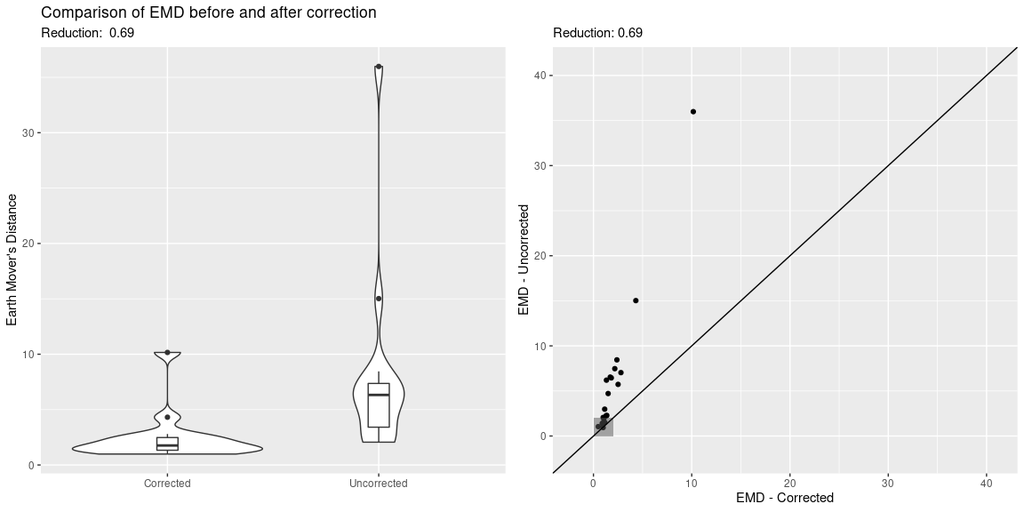

```r
corrected$label <- uncorrected$label <- 1 # We set all labels to 1 in order to evaluate globally

emd <- evaluate_emd(uncorrected = uncorrected,
                    corrected = corrected)

cowplot::plot_grid(emd$violin, emd$scatterplot)
```

Finally, let us look at some plots to visualize the correction. First, the marker distributions before and after:

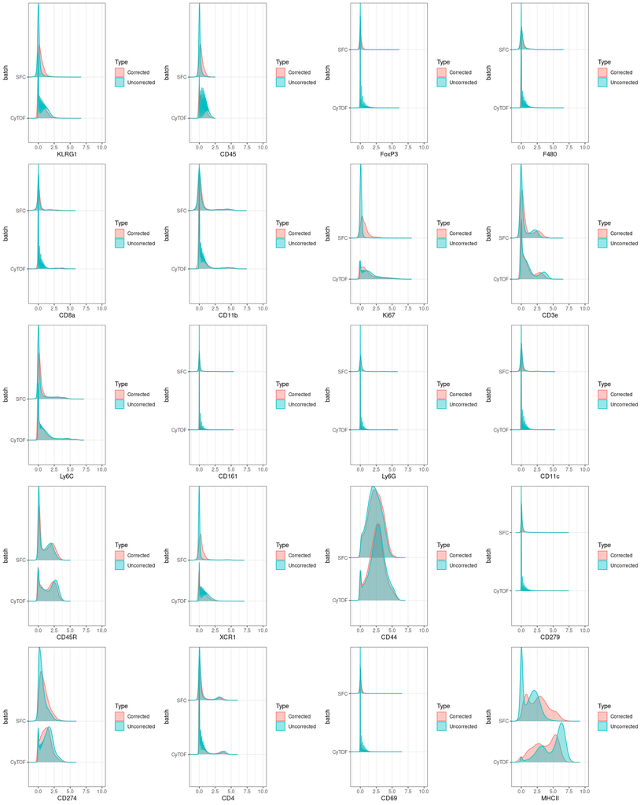

```r
plot_density(uncorrected, corrected, ncol = 4)
```

Finally, some UMAPs to visualize the correction. I will downsample to 10,000 cells from each dataset so it is easier to see what is going on.

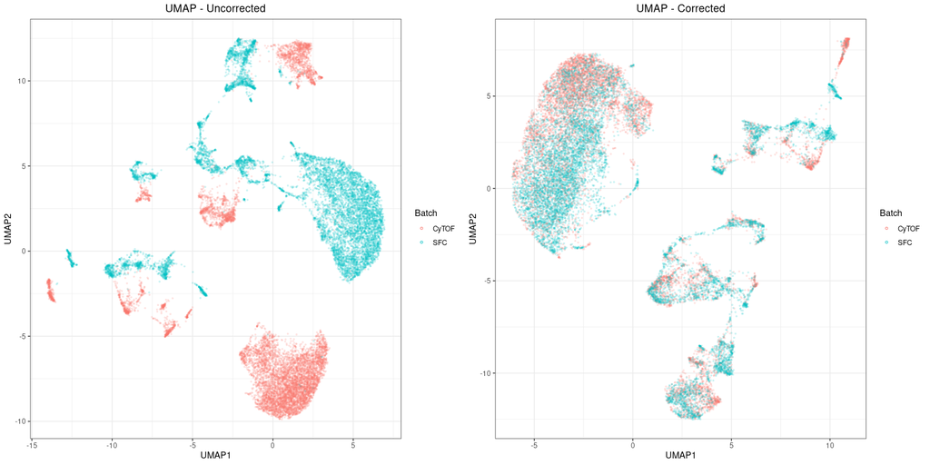

```r
inds <- split(1:length(uncorrected$batch), uncorrected$batch)
sample <- unlist(lapply(inds, sample, 10000))

plot1 <- plot_dimred(uncorrected[sample,], name = 'Uncorrected', type = 'umap')
plot2 <- plot_dimred(corrected[sample,], name = 'Corrected', type = 'umap')

cowplot::plot_grid(plot1, plot2)
```

## Distinct datasets

First, let us present the two datasets we will integrate:

As an example of spectral flow cytometry data, we will use the dataset from [Park et al. (2020)](https://doi.org/10.1002/cyto.a.24213). The data is based on healthy donor PBMCs, and contains four samples, which were frozen and thawed, stained with 40 different antibodies in one panel, and analysed using a 5-laser full spectrum flow cytometer (Cytek Biosciences Aurora). We downloaded these from FlowRepository (ID: FR-FCM-Z2QV) and pre-gated to live single cells in FlowJo version 10 (Tree Star Inc). Singlets and non-debris were identified using forward and side-scatter. Dead cells were excluded using live/dead stains. Data from these gates were then exported in FCS format.

For the CyTOF data, we use the data from a single healthy donor processed at the Human Immune Monitoring Center, Stanford. The sample was derived from FlowRepository https://flowrepository.org/id/FR-FCM-ZYAJ and pre-gated to live intact singlets. The data was subsequently manually gated to populations of interest.

We start by loading some packages-

```r
library(cyCombine)
library(tidyverse)
```

#### Loading data

##### Spectral flow cytometry data

We are now ready to load the spectral flow data. We have set up a panel file in csv format, so the correct information is extractable from there. Let us have a look at the contents:

```r
# Directory with raw .fcs files
data_dir <- "Park_et_al_2020_Live+/"

# Panel and reading data
sfc_panel <- read_csv(paste0(data_dir, "/panel_Park2020.csv"))
sfc_panel
```

| Channel | Marker | Type |
| --- | --- | --- |
| FSC-A | FSC-A | none |
| FSC-H | FSC-H | none |
| SSC-A | SSC-A | none |
| SSC-B-A | SSC-B-A | none |
| SSC-B-H | SSC-B-H | none |
| SSC-H | SSC-H | none |
| FJComp-APC-A | CD159a | type |
| FJComp-APC-Fire810-A | CD38 | type |
| FJComp-APC-H7-A | CD27 | type |
| FJComp-APC-R700-A | CD127 | type |

[output cut: 37 more lines]

We then progress with reading the spectral flow dataset and converting it to a tibble format, which is easy to process. We use cofactor = 6000 for spectral flow data asinh-transformation. This looks reasonable in terms of separating negative and positive peaks in the data, and it was further recommended by [Ferrer-Font et al. (2020)](https://doi.org/10.1002/cyto.a.24016).

```r
sfc_markers <- sfc_panel %>%
  filter(Type != "none") %>%
  pull(Marker) %>%
  str_remove_all("[ _-]")

spectral <- prepare_data(data_dir = data_dir,
                         metadata = paste0(data_dir, "/Spectral samples cohort.xlsx"),
                         filename_col = "FCS_name",
                         batch_ids = "Batch",
                         condition = "Set",
                         cofactor = 6000,
                         derand = FALSE,
                         markers = sfc_markers,
                         down_sample = FALSE)
```

```
Reading 4 files to a flowSet..
```

```
Extracting expression data..
```

```
Your flowset is now converted into a dataframe.
```

```
Transforming data using asinh with a cofactor of 6000..
```

```
Done!
```

##### Mass cytometry data

Then it is time to read the CyTOF data. In this case, it’s already in a tibble format - but refer to `prepare_data` as shown above, for this.

```r
### Get HIMC cytof data for one sample
load('Sample001_pregated.Rdata')
```

#### Processing datasets - batch correction

Next, we need to figure out which markers to use when integrating the two datasets. Here, it is important to keep a couple of things in mind.

First, be careful with protein names - i.e. CD197 and CCR7 are actually the same protein, but each name is relatively commonly used. Make sure to correct the column names in either set, so it matches the other, i.e. using `colnames(cytof)[colnames(cytof)=='CD197'] <- 'CCR7'`. In this example, there are a total of 26 overlapping markers between the two datasets.

```r
colnames(cytof)[colnames(cytof)=='CD197'] <- 'CCR7'
colnames(cytof)[colnames(cytof)=='CD8a'] <- 'CD8'

cytof_markers <- get_markers(cytof)
intersect(sfc_markers, cytof_markers)
```

```
 [1] "CD38"   "CD27"   "CD127"  "CD45RA" "CD16"   "CD56"   "CD8"    "CCR7"
 [9] "IgD"    "CD3"    "CD28"   "CCR6"   "CXCR5"  "PD1"    "CD4"    "CD57"
[17] "CD24"   "CD25"   "CXCR3"  "HLADR"  "CD20"   "TCRgd"  "CD14"   "CD19"
[25] "CD123"  "CD11c"
```

Now, we are ready to combine the two datasets on the overlapping columns.

```r
# Get overlapping column names
overlap_cols <- intersect(colnames(spectral), colnames(cytof))

# Make one tibble
uncorrected <- bind_rows(cytof[,overlap_cols], spectral[,overlap_cols]) %>%
  mutate(id = 1:(nrow(cytof)+nrow(spectral)))
```

And now, batch correction can be performed with cyCombine.

```r
# Run batch correction
corrected <- uncorrected %>%
  batch_correct(xdim = 8,
                ydim = 8,
                norm_method = 'rank',
                ties.method = 'average',
                rlen = 100)
```

#### Evaluating performance

We now evaluate the correction using EMD - each marker is evaluated across all cells.

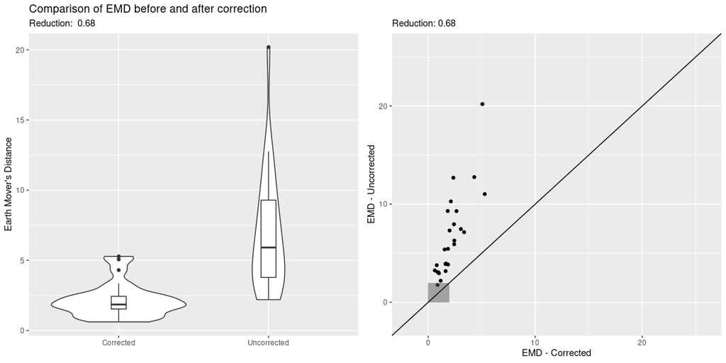

```r
corrected$label <- uncorrected$label <- 1 # We set all labels to 1 in order to evaluate globally

emd <- evaluate_emd(uncorrected = uncorrected,
                    corrected = corrected)

cowplot::plot_grid(emd$violin, emd$scatterplot)
```

Finally, let us look at some plots to visualize the correction. First, the marker distributions before and after:

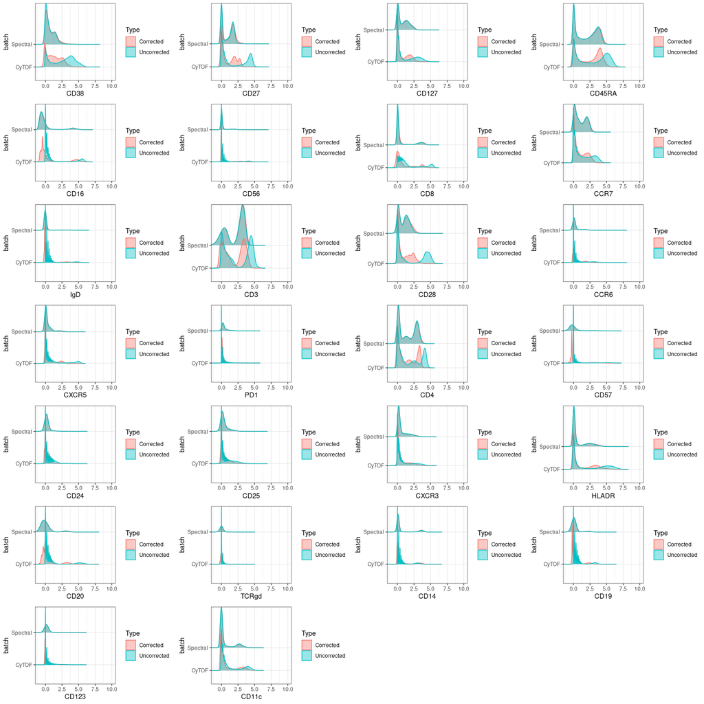

```r
plot_density(uncorrected, corrected, ncol = 4)
```

Finally, some UMAPs to visualize the correction. I will downsample to 10,000 cells from each dataset so it is easier to see what is going on.

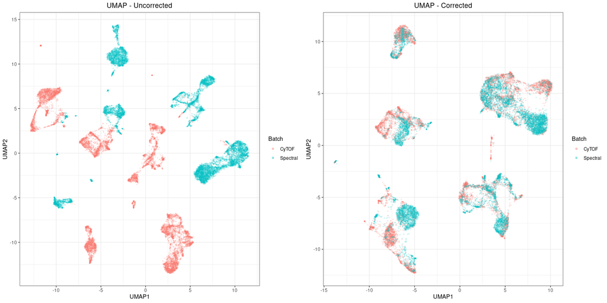

```r
inds <- split(1:length(uncorrected$batch), uncorrected$batch)
sample <- unlist(lapply(inds, sample, 10000))

plot1 <- plot_dimred(uncorrected[sample,], name = 'Uncorrected', type = 'umap')
plot2 <- plot_dimred(corrected[sample,], name = 'Corrected', type = 'umap')

cowplot::plot_grid(plot1, plot2)
```

#### Imputing non-overlapping markers

Now, we could say that the integration is done. We have an strong idea about which cells belong in the same populations across the two technologies. But we may really curious about the non-overlapping channels. E.g. let us have a brief look on the immunoglobulins (IgD, IgM, IgG). All of these are measured in the spectral flow dataset - only IgD is included in the CyTOF data. These three proteins should also be found only among the B-cells (CD19+/CD20+). This should be true even after imputation.

We will impute all the markers missing in either dataset first.

```r
# Get the dataset-unique markers
spectral_unique <- sfc_markers[!sfc_markers %in% overlap_cols]
cytof_unique <- cytof_markers[!cytof_markers %in% overlap_cols]


# Add non-overlapping markers back to corrected data frames
cytof_corrected <- bind_cols(corrected[corrected$batch == 'CyTOF',], cytof[,cytof_unique])
spectral_corrected <- bind_cols(corrected[corrected$batch == 'Spectral',], spectral[,spectral_unique])


# Imputation for whole panels
imputed <- impute_across_panels(dataset1 = cytof_corrected,
                                dataset2 = spectral_corrected,
                                overlap_channels = intersect(sfc_markers, cytof_markers),
                                impute_channels1 = spectral_unique,
                                impute_channels2 = cytof_unique)
```

```
Creating SOM grid..
```

```
Performing density draws for dataset1.
Performing density draws for dataset2.
```

Now that we have imputed the values, we have a chance to view the IgG / IgM expression for both datasets. We will look at this along with the CD19, CD20, and IgD expression.

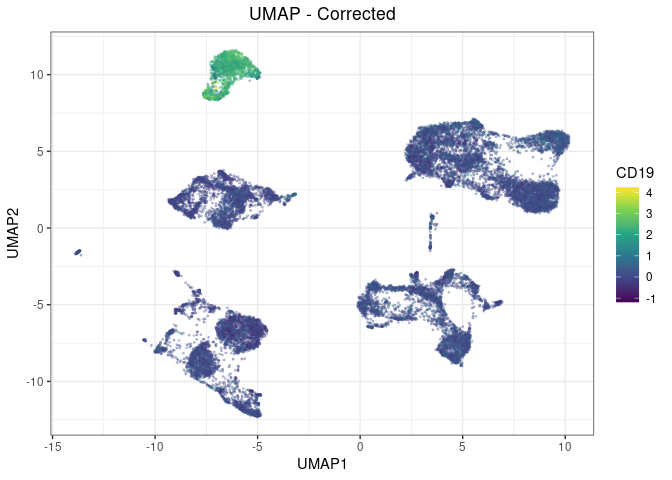

```r
# Let us make the UMAP for the corrected set (based on overlapping markers only)
umap_plot <- plot_dimred(corrected[sample,], name = 'Corrected', type = 'umap', plot = 'CD19', return_coord = T)

# We can view the plot colored by CD19 expression
umap_plot$plot
```

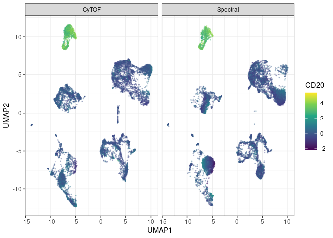

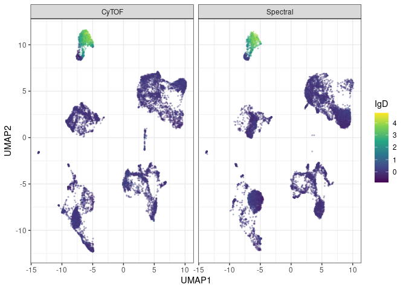

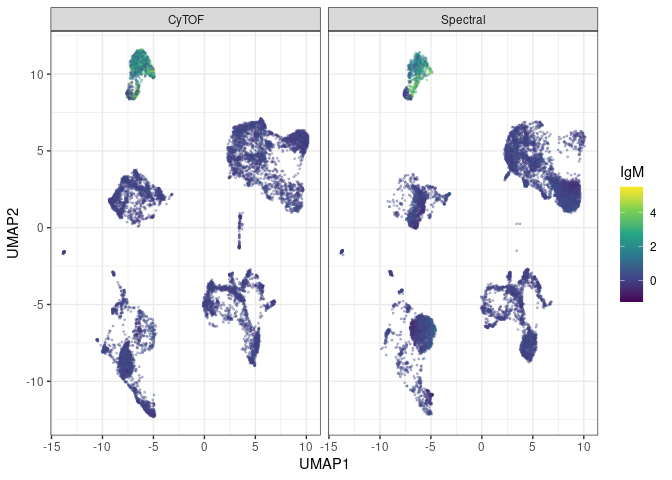

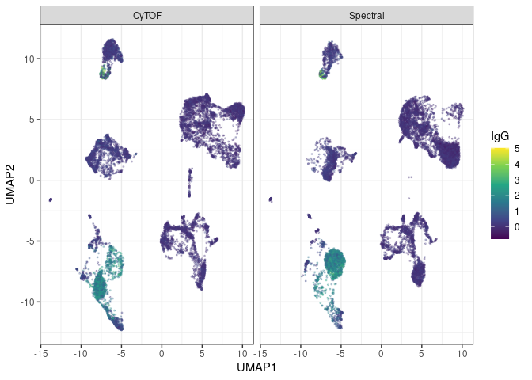

```r
# We can further include the UMAP coordinates in a combined dataframe with both imputed datasets. Again, we downsample to avoid too many cells cluttering the view (the same indeces are used as before)
combined <- cbind.data.frame(umap_plot$dimred, rbind.data.frame(imputed$dataset1, imputed$dataset2)[sample,])


# Now let us color the plot by the two other overlapping markers which are B cell-relevant

p <- list()
for (m in c('CD20', 'IgD', 'IgM', 'IgG')) {

  p[[m]] <- ggplot(combined, aes_string(x = colnames(combined)[1], y = colnames(combined)[2])) +
  geom_point(aes_string(color = m), alpha = 0.3, size = 0.4) +
  theme_bw() + theme(plot.title = element_text(hjust = 0.5)) +
  scale_color_viridis_c() + facet_wrap(~batch)

}

p
```

We can compare this to UMAPs for the spectral flow data only (before any batch correction):

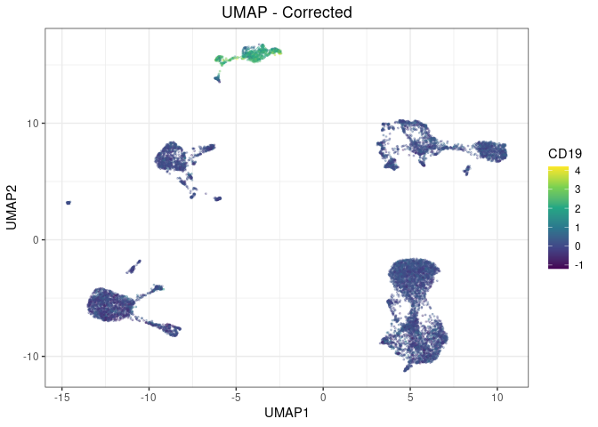

```r
# Let us make the UMAP for the corrected set (based on overlapping markers only)
spectral_sample <- (sample[grep('Spectral', names(sample))]-nrow(cytof))
umap_plot <- plot_dimred(spectral[spectral_sample,], name = 'Corrected', type = 'umap', plot = 'CD19', return_coord = T)

# We can view the plot colored by CD19 expression
umap_plot$plot
```

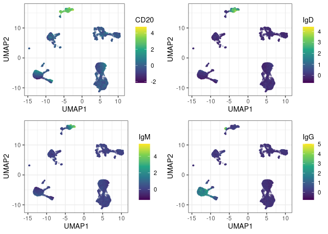

```r
# We can further include the UMAP coordinates in a combined dataframe with both imputed datasets. Again, we downsample to avoid too many cells cluttering the view (the same indeces are used as before)
combined <- cbind.data.frame(umap_plot$dimred, spectral[spectral_sample,])


# Now let us color the plot by the two other overlapping markers which are B cell-relevant

p <- list()
for (m in c('CD20', 'IgD', 'IgM', 'IgG')) {

  p[[m]] <- ggplot(combined, aes_string(x = colnames(combined)[1], y = colnames(combined)[2])) +
  geom_point(aes_string(color = m), alpha = 0.3, size = 0.4) +
  theme_bw() + theme(plot.title = element_text(hjust = 0.5)) +
  scale_color_viridis_c()

}

cowplot::plot_grid(plotlist = p, ncol = 2)
```

The distributions look quite well-transfered to the CyTOF data.